# Análise Exploratória

Teh Led Red

20/09/2020

### Variáveis contínuas: age, trestbps, chol, thalach e oldpeak.

#### Distribuição

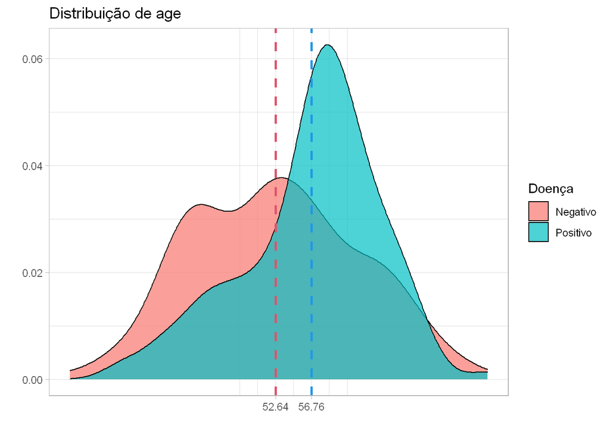

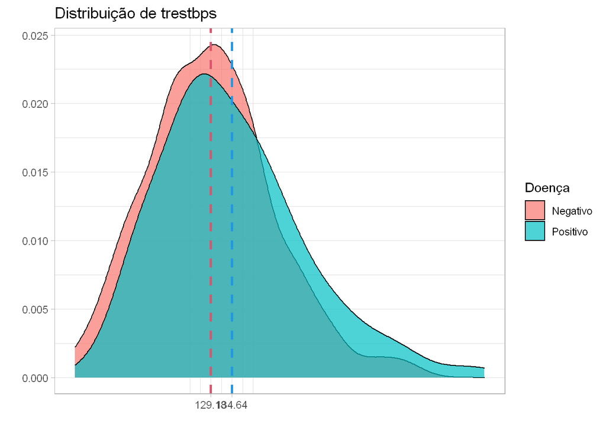

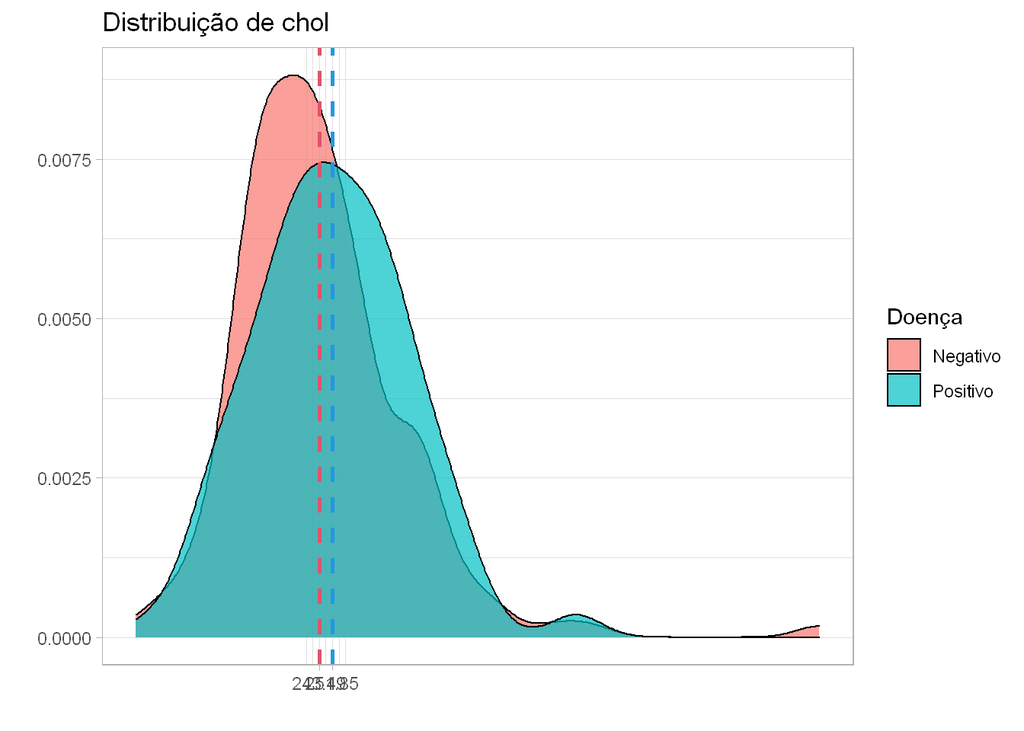

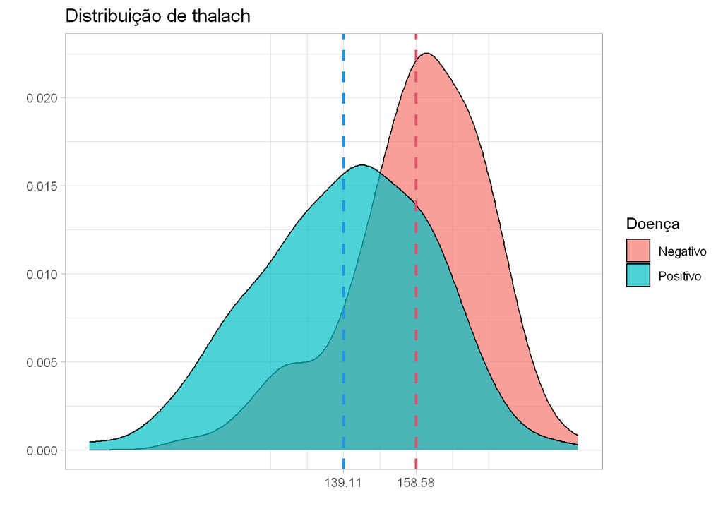

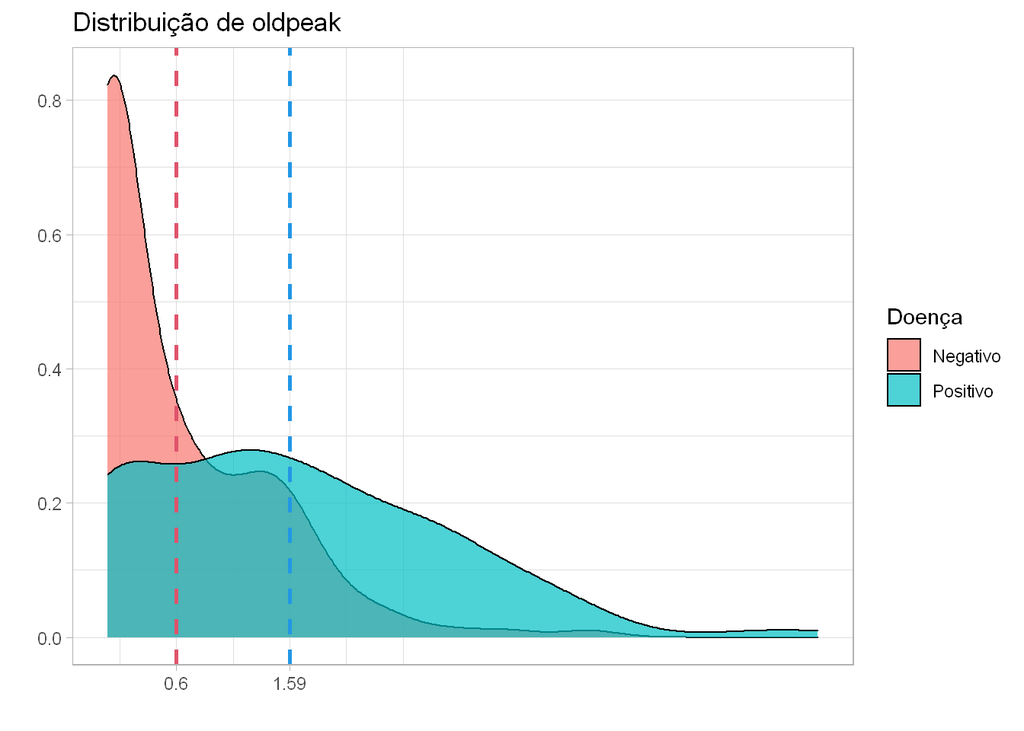

Por meio da comparação entre densidade estimada para grupo com e sem doença no gráfico da distribuição de cada variável contínua, notamos que em geral não existe uma divisão óbvia entre distribuição com e sem doença em cada variável. Para a variável *age*, percebe-se que a distribuição de idade para grupo com doença tem maior concentração nas idades avançadas sendo que a média igual 56,76. Para a variável *thalach* e *oldpeak*, apesar de possuir muita área em sobreposição entre dois grupos, percebe-se que a dispersão do grupo com doença é mais larga. O grupo com doença possui uma média na frequência cardíaca máxima (*thalach*) menor que o grupo sem doença (139,11 e 158,58) e uma média de oldpeak maior em relação ao grupo sem doença (1,59 e 0,6).

#### Correlação

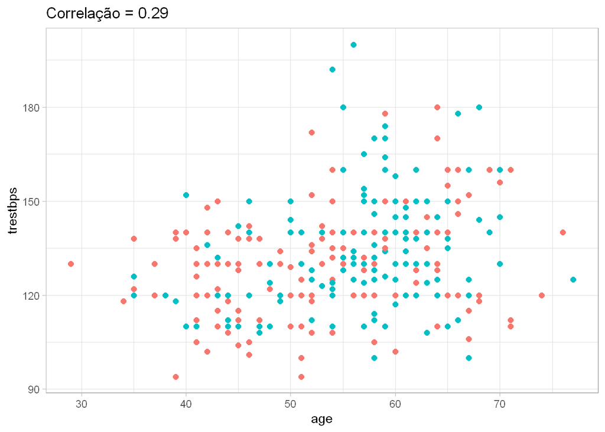

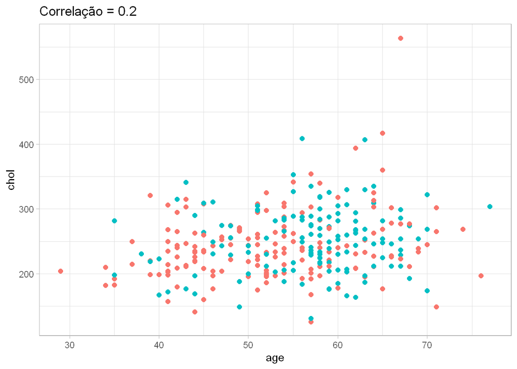

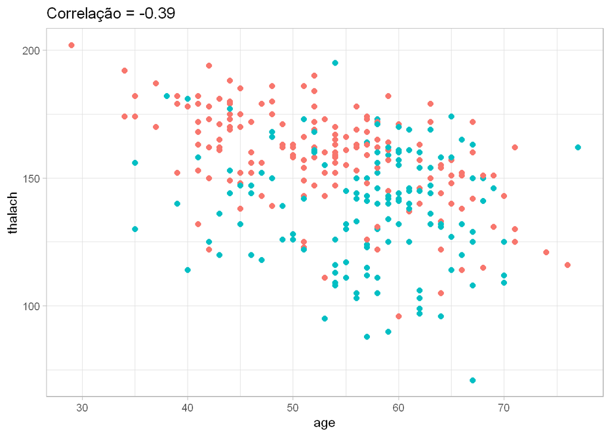

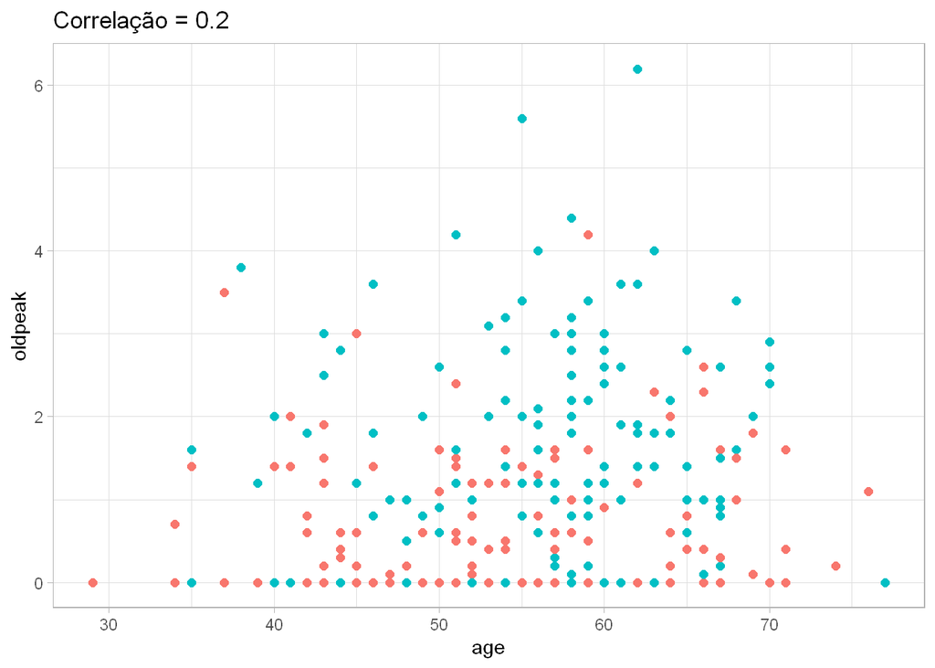

De modo geral, as variáveis não são fortemente correlacionados. O maior correlação é o par de *age* e *thalach* cujo coeficiente de Pearson é -0,39, isso indica que a frequência cardíaca máxima tende a diminuir conforme o aumento da idade. Visualmente, o grupo com a doença parece possuir uma frequência menor em comparação ao grupo de sem doença.

### Variáveis categóricas: sex, cp, fbs, restecg, exang, slope, ca, thal.

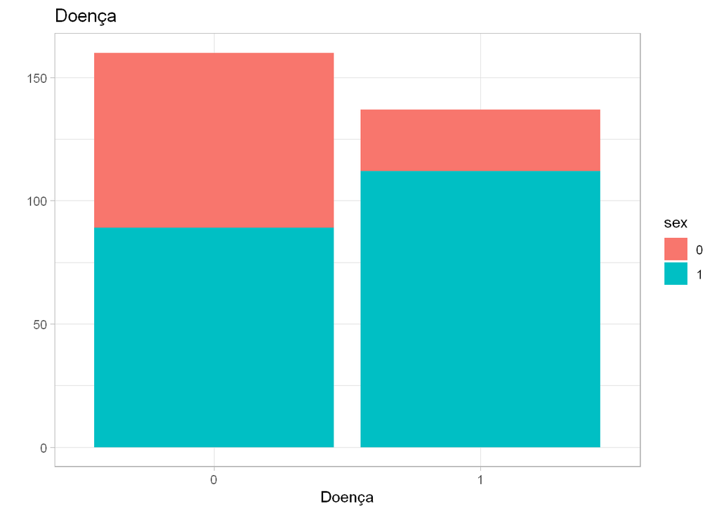

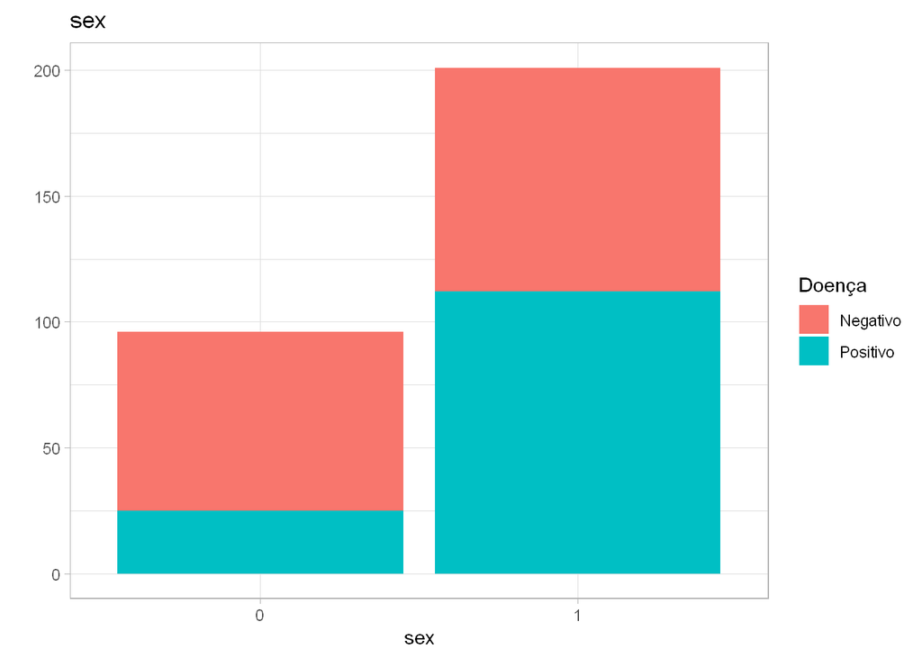

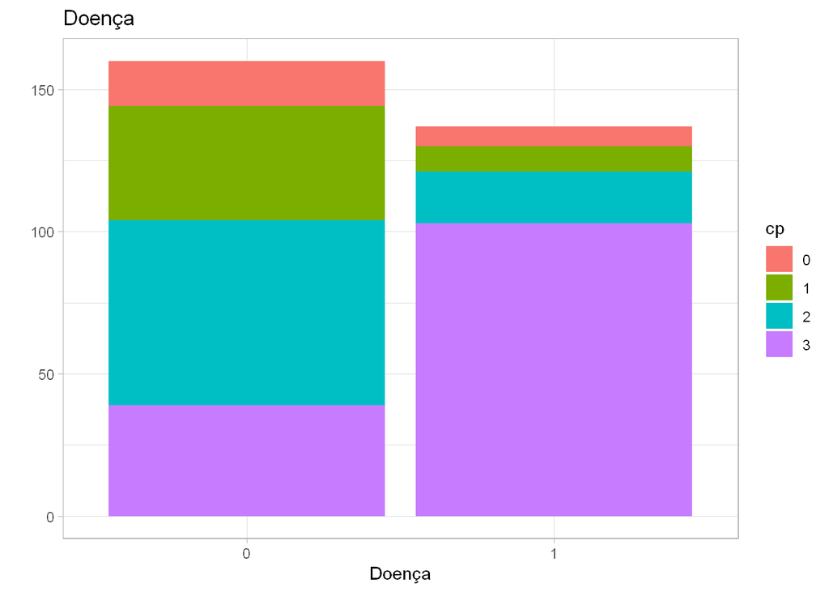

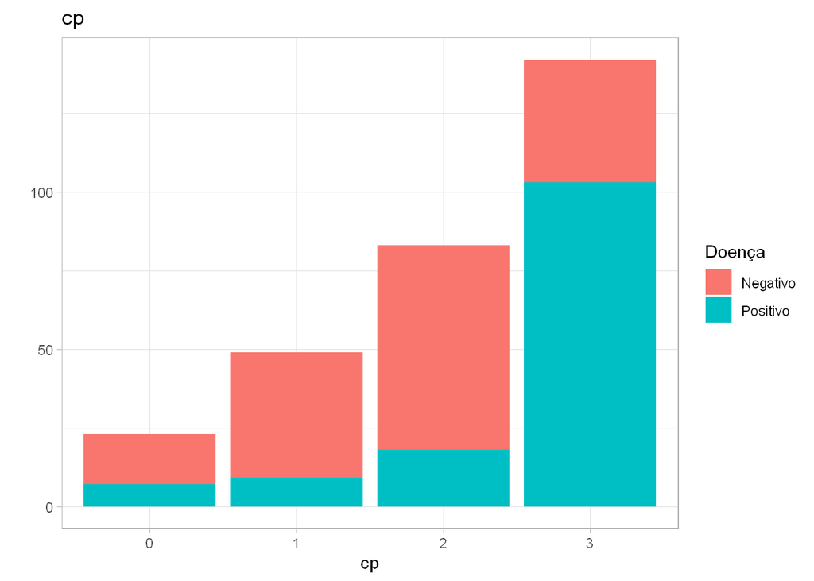

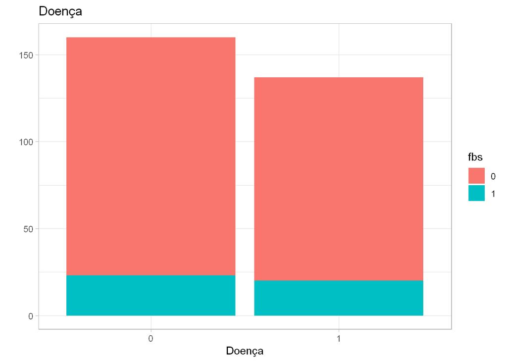

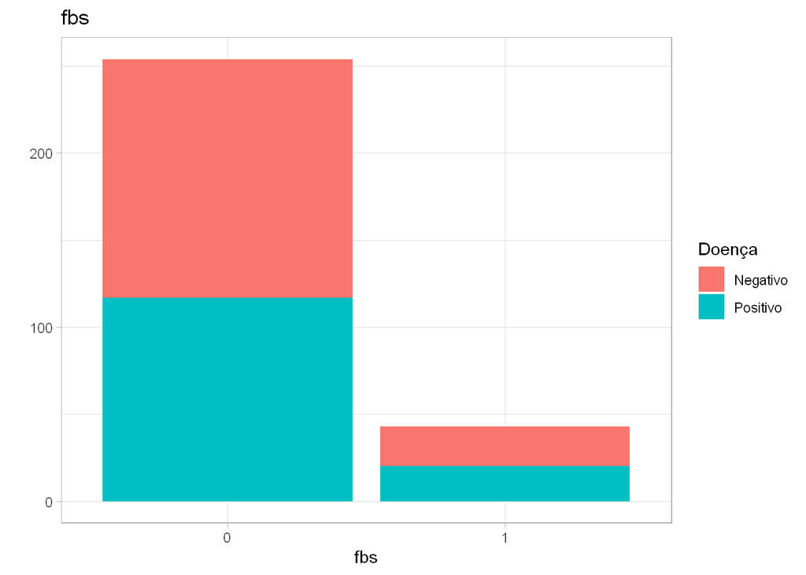

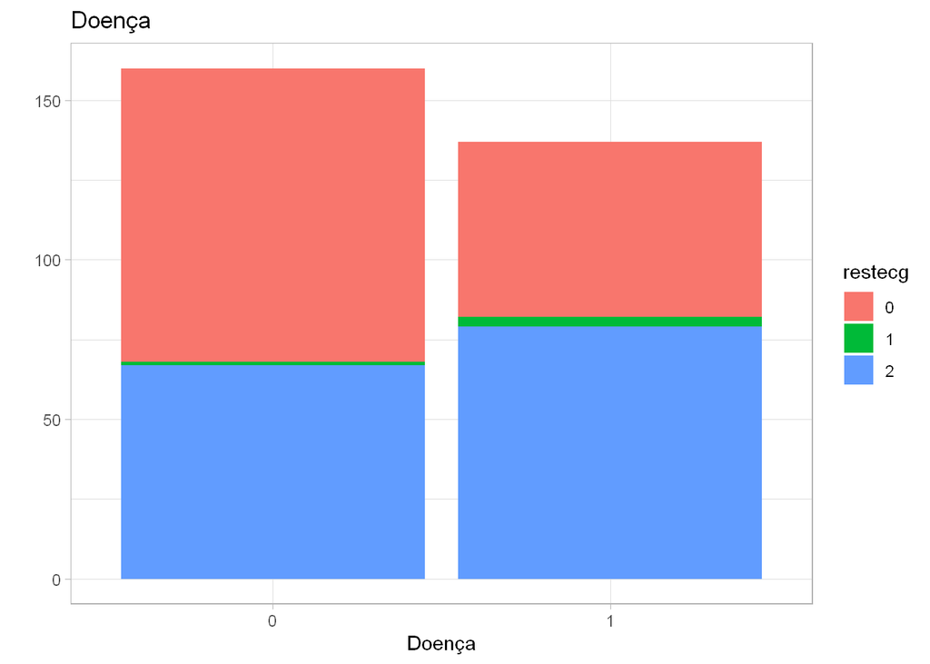

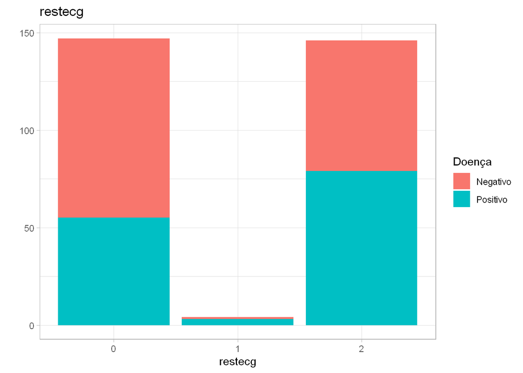

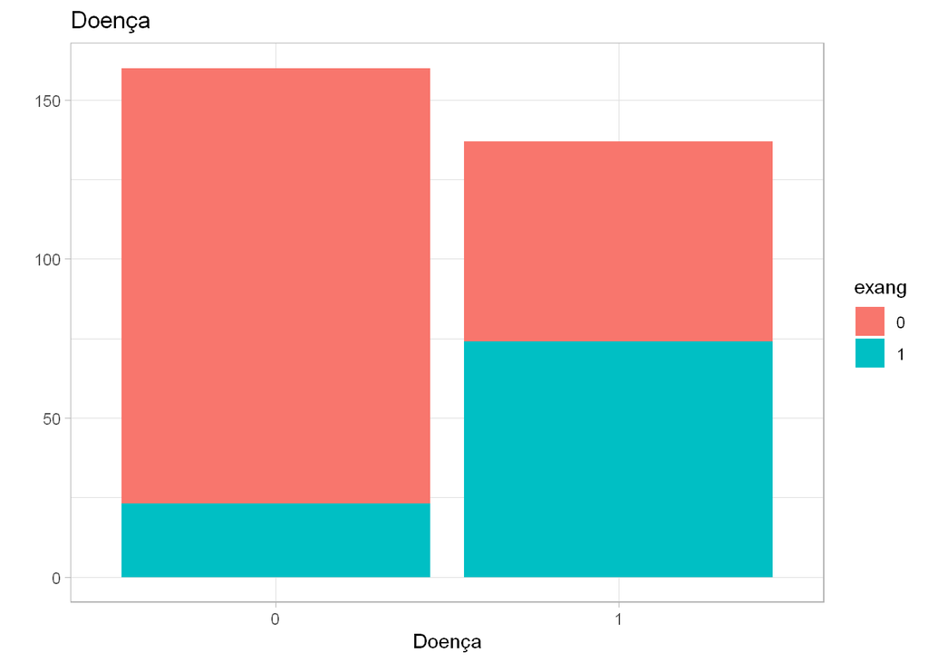

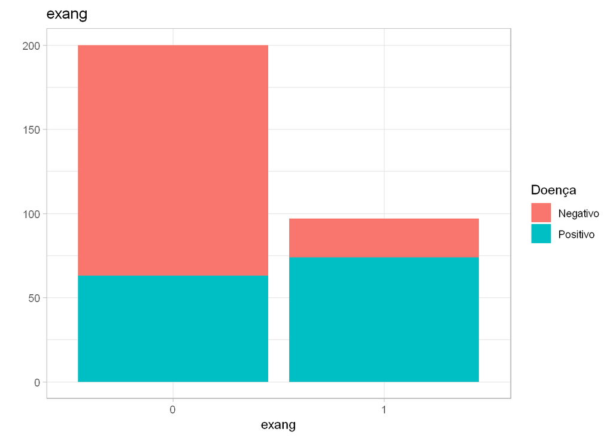

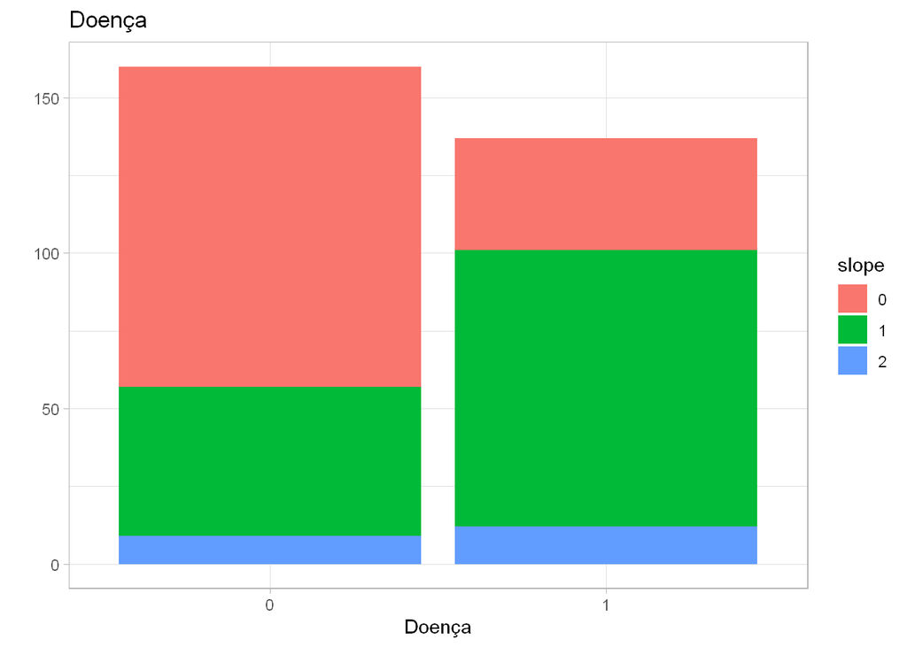

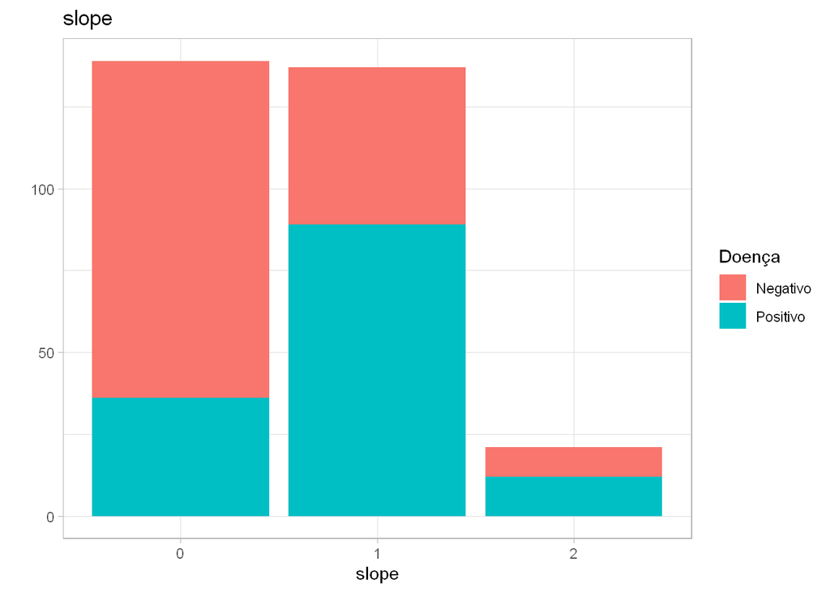

[4 more figures not shown]

Para cada variável categórica é plotado dois gráficos de barra, o primeiro tem no seu eixo X $0:$ grupo sem doença e $1:$ grupo com doença e eixo Y a contagem de frequência, cada barra do grupo consiste a proporção corresponde ao nível da variável categórica estudada. Já o segundo gráfico de barra faz o contrário, tem no seu eixo X o número inteiro indicativo ao nível correpondente da variável categórica estudada e o eixo Y a contagem de frequência, cada barra do nível consiste a composição de proporção do grupo com e sem doença.

Note-se a distribuição dos níveis em algumas variáveis não é homogênea entre grupo com e sem doença: *cp*, *exang*, *slope*, *ca* e *thal*, isso indica que essas variáveis podem ser candidatos aos fatores principais na modelagem. A seguir é apresentada a tabela que contem a *mutual information* calculada para cada variável categórica com o indicador de doença ($I(x,y)$).

**Mutual information**

| sex | cp | fbs | restecg | exang | slope | ca | thal |
| --- | --- | --- | --- | --- | --- | --- | --- |
| 0.0401 | 0.1367 | 0 | 0.0163 | 0.0917 | 0.0754 | 0.128 | 0.1457 |